# Analyse User Engagement on an Online Learning Platform

## Data Cleaning & Preparation

```python
import pandas as pd
import matplotlib.pyplot as plt
import seaborn as sns
```

```python
# Loading Datasets
Students = pd.read_csv("C:\\Users\\vishn\\Desktop\\students.csv")
Course_Activity = pd.read_csv("C:\\Users\\vishn\\Desktop\\course_activity.csv")
Feedback = pd.read_csv("C:\\Users\\vishn\\Desktop\\feedback.csv")
```

```python
Students.head()
```

|  | Student_ID | Name | Age | Gender | Location | Enrolment_Date |
| --- | --- | --- | --- | --- | --- | --- |
| 0 | S001 | Student_1 | 24 | Female | Kolkata | 24-11-2023 |
| 1 | S002 | Student_2 | 32 | Other | Chennai | 27-02-2023 |
| 2 | S003 | Student_3 | 28 | Other | Mumbai | 13-01-2023 |
| 3 | S004 | Student_4 | 25 | Female | Bangalore | 21-05-2023 |
| 4 | S005 | Student_5 | 24 | Other | Delhi | 06-05-2023 |

```python
Students.dtypes
```

```
Student_ID        object
Name              object
Age                int64
Gender            object
Location          object
Enrolment_Date    object
dtype: object
```

```python
Course_Activity.head()
```

|  | Student_ID | Course_ID | Date | Time_Spent_Minutes | Completion_Percentage |
| --- | --- | --- | --- | --- | --- |
| 0 | S001 | PY202 | 05-01-2024 | 90 | 46.10 |
| 1 | S001 | DM101 | 28-01-2024 | 155 | 88.87 |
| 2 | S001 | UX303 | 28-01-2024 | 177 | 54.93 |
| 3 | S002 | PY202 | 03-02-2024 | 45 | 32.20 |
| 4 | S002 | UX303 | 15-03-2024 | 119 | 90.80 |

```python
Course_Activity.dtypes
```

```
Student_ID                object
Course_ID                 object
Date                      object
Time_Spent_Minutes         int64
Completion_Percentage    float64
dtype: object
```

```python
Feedback.head()
```

|  | Student_ID | Course_ID | Rating | Feedback_Text |
| --- | --- | --- | --- | --- |
| 0 | S057 | UX303 | 2 | Too fast-paced |
| 1 | S063 | PY202 | 2 | Loved the examples |
| 2 | S022 | PY202 | 4 | Could be better |
| 3 | S011 | PY202 | 5 | Needs improvement |
| 4 | S073 | WD404 | 4 | Could be better |

```python
Feedback.dtypes
```

```
Student_ID       object
Course_ID        object
Rating            int64
Feedback_Text    object
dtype: object
```

```python
# Checking for missing values
print("Missing values in Students:", Students.isnull().sum())
print("\nMissing values in Course Activity:", Course_Activity.isnull().sum())
print("\nMissing values in Feedback:", Feedback.isnull().sum())
```

```
Missing values in Students: Student_ID        0
Name              0
Age               0
Gender            0
Location          0
Enrolment_Date    0
dtype: int64

Missing values in Course Activity: Student_ID               0
Course_ID                0
Date                     0
Time_Spent_Minutes       0
Completion_Percentage    0
dtype: int64

Missing values in Feedback: Student_ID       0
Course_ID        0
Rating           0
Feedback_Text    0
dtype: int64
```

```python
# Checking for Duplicates
print("\nDuplicate Students:", Students.duplicated().sum())
print("Duplicate Course Activities:", Course_Activity.duplicated().sum())
print("Duplicate Feedback entries:", Feedback.duplicated().sum())
```

```
Duplicate Students: 0
Duplicate Course Activities: 0
Duplicate Feedback entries: 0
```

**The data appears clean with no missing values or duplicates.**

```python
Students['Enrolment_Date'] = pd.to_datetime(Students['Enrolment_Date'], format='%d-%m-%Y')
Course_Activity['Date'] = pd.to_datetime(Course_Activity['Date'], format='%d-%m-%Y')
```

```python
Students.dtypes
```

```
Student_ID                object
Name                      object
Age                        int64
Gender                    object
Location                  object
Enrolment_Date    datetime64[ns]
dtype: object
```

```python
Course_Activity.dtypes
```

```
Student_ID                       object
Course_ID                        object
Date                     datetime64[ns]
Time_Spent_Minutes                int64
Completion_Percentage           float64
dtype: object
```

```python
Feedback.dtypes
```

```
Student_ID       object
Course_ID        object
Rating            int64
Feedback_Text    object
dtype: object
```

**Date columns have been properly converted.**

## Exploratory Data Analysis (EDA)

#### Overall average completion rate across courses

```python
avg_completion = Course_Activity['Completion_Percentage'].mean()
print("Percentage(%):",avg_completion)
print("Roundoff Percentage(%):",round(avg_completion))
```

```
Percentage(%): 54.77871016691957
Roundoff Percentage(%): 55
```

**Overall average completion rate: 54.78% ~ 55%**

#### Course with highest and lowest average engagement time

```python
Course_Engagement = Course_Activity.groupby('Course_ID')['Time_Spent_Minutes'].mean().sort_values()
print("\nCourses by Average Engagement Time:")
print(Course_Engagement)
```

```
Courses by Average Engagement Time:
Course_ID
PY202     93.902439
WD404     96.419162
UX303     99.816568
DM101    102.427673
Name: Time_Spent_Minutes, dtype: float64
```

**Highest engagement: DM101 (102.42 Minutes)**

**Lowest engagement: PY202 (93.90 Minutes)**

#### Engagement by age group

```python
# Merge data for demographic analysis
merged_data = pd.merge(Course_Activity, Students, on='Student_ID')
```

```python
merged_data.head()
```

|  | Student_ID | Course_ID | Date | Time_Spent_Minutes | Completion_Percentage | Name | Age | Gender | Location | Enrolment_Date |
| --- | --- | --- | --- | --- | --- | --- | --- | --- | --- | --- |
| 0 | S001 | PY202 | 2024-01-05 | 90 | 46.10 | Student_1 | 24 | Female | Kolkata | 2023-11-24 |
| 1 | S001 | DM101 | 2024-01-28 | 155 | 88.87 | Student_1 | 24 | Female | Kolkata | 2023-11-24 |
| 2 | S001 | UX303 | 2024-01-28 | 177 | 54.93 | Student_1 | 24 | Female | Kolkata | 2023-11-24 |
| 3 | S002 | PY202 | 2024-02-03 | 45 | 32.20 | Student_2 | 32 | Other | Chennai | 2023-02-27 |
| 4 | S002 | UX303 | 2024-03-15 | 119 | 90.80 | Student_2 | 32 | Other | Chennai | 2023-02-27 |

```python
# Create age groups
bins = [15, 20, 25, 30, 35]
labels = ['15-20', '21-25', '26-30', '31-35']
merged_data['Age_Group'] = pd.cut(merged_data['Age'], bins=bins, labels=labels)
```

```python
merged_data.head()
```

|  | Student_ID | Course_ID | Date | Time_Spent_Minutes | Completion_Percentage | Name | Age | Gender | Location | Enrolment_Date | Age_Group |
| --- | --- | --- | --- | --- | --- | --- | --- | --- | --- | --- | --- |
| 0 | S001 | PY202 | 2024-01-05 | 90 | 46.10 | Student_1 | 24 | Female | Kolkata | 2023-11-24 | 21-25 |
| 1 | S001 | DM101 | 2024-01-28 | 155 | 88.87 | Student_1 | 24 | Female | Kolkata | 2023-11-24 | 21-25 |
| 2 | S001 | UX303 | 2024-01-28 | 177 | 54.93 | Student_1 | 24 | Female | Kolkata | 2023-11-24 | 21-25 |
| 3 | S002 | PY202 | 2024-02-03 | 45 | 32.20 | Student_2 | 32 | Other | Chennai | 2023-02-27 | 31-35 |
| 4 | S002 | UX303 | 2024-03-15 | 119 | 90.80 | Student_2 | 32 | Other | Chennai | 2023-02-27 | 31-35 |

```python
merged_data.dtypes
```

```
Student_ID                       object
Course_ID                        object
Date                     datetime64[ns]
Time_Spent_Minutes                int64
Completion_Percentage           float64
Name                             object
Age                               int64
Gender                           object
Location                         object
Enrolment_Date           datetime64[ns]
Age_Group                      category
dtype: object
```

```python
age_engagement = merged_data.groupby('Age_Group')['Time_Spent_Minutes'].mean()
print("\nEngagement by age group:")
print(age_engagement)
```

```
Engagement by age group:
Age_Group
15-20     99.416107
21-25    101.828877
26-30     95.867403
31-35     94.718310
Name: Time_Spent_Minutes, dtype: float64
```

**Age Engagement:**

**15-20 : 99.41 Minutes**

**21-25 : 101.82 Minutes**

**26-30 : 95.86 Minutes**

**31-35 : 94.71 Minutes**

#### Engagement by location

```python
location_engagement = merged_data.groupby('Location')['Time_Spent_Minutes'].mean().sort_values(ascending=False)
print("\nEngagement by location:")
print(location_engagement)
```

```
Engagement by location:
Location
Kolkata      104.384615
Delhi        103.302857
Bangalore     98.000000
Mumbai        95.435484
Chennai       90.946746
Name: Time_Spent_Minutes, dtype: float64
```

**Engagement by Location:**

**Kolkata : 104.38 minutes**

**Delhi : 103.30 minutes**

**Bangalore : 98.00 minutes**

**Mumbai : 95.43 minutes**

**Chennai : 90.94 minutes**

#### Average feedback rating per course

```python
Course_Ratings = Feedback.groupby('Course_ID')['Rating'].mean().sort_values(ascending=False)
print("\nAverage feedback rating per course:")
print(Course_Ratings)
```

```
Average feedback rating per course:
Course_ID
PY202    3.277778
UX303    2.923077
DM101    2.900000
WD404    2.789474
Name: Rating, dtype: float64
```

**Course Ratings:**

**PY202 : 3.27**

**UX303 : 2.92**

**DM101 : 2.90**

**WD404 : 2.78**

#### Correlation between completion rate and feedback rating

```python
# Merge course activity with feedback
Activity_Feedback = pd.merge(Course_Activity, Feedback, on=['Student_ID', 'Course_ID'], how='inner')
Activity_Feedback.head()
```

|  | Student_ID | Course_ID | Date | Time_Spent_Minutes | Completion_Percentage | Rating | Feedback_Text |
| --- | --- | --- | --- | --- | --- | --- | --- |
| 0 | S002 | PY202 | 2024-02-03 | 45 | 32.20 | 3 | Well structured |
| 1 | S002 | PY202 | 2024-03-06 | 136 | 18.18 | 3 | Well structured |
| 2 | S005 | DM101 | 2024-01-30 | 27 | 91.49 | 4 | Loved the examples |
| 3 | S006 | DM101 | 2024-03-27 | 177 | 98.57 | 1 | Loved the examples |
| 4 | S006 | DM101 | 2024-01-08 | 113 | 75.54 | 1 | Loved the examples |

```python
Correlation = Activity_Feedback['Completion_Percentage'].corr(Activity_Feedback['Rating'])
print(Correlation)
```

```
-0.05170765814948301
```

**Correlation between completion rate and feedback rating: -0.05 (Negative Correlation)**

#### Top 3 student segments based on engagement and satisfaction

```python
# Create engagement score (time spent * completion percentage)
merged_data['Engagement_Score'] = merged_data['Time_Spent_Minutes'] * (merged_data['Completion_Percentage']/100)

# Merge with feedback for satisfaction
Engagement_Satisfaction = pd.merge(merged_data, Feedback, on=['Student_ID', 'Course_ID'], how='left')

# Group by demographic segments and calculate average engagement and rating
Segments = Engagement_Satisfaction.groupby(['Age_Group', 'Gender', 'Location']).agg({'Engagement_Score': 'mean','Rating': 'mean'}).sort_values(['Engagement_Score', 'Rating'], ascending=False)
print("\nTop 3 Student Segments:")
print(Segments.head(3))
```

```
Top 3 Student Segments:
                           Engagement_Score  Rating
Age_Group Gender Location
21-25     Other  Mumbai           86.722025     NaN
          Female Kolkata          83.427757     NaN
          Other  Kolkata          79.825385     2.0
```

**Top 3 Segments:**

## Visualizations

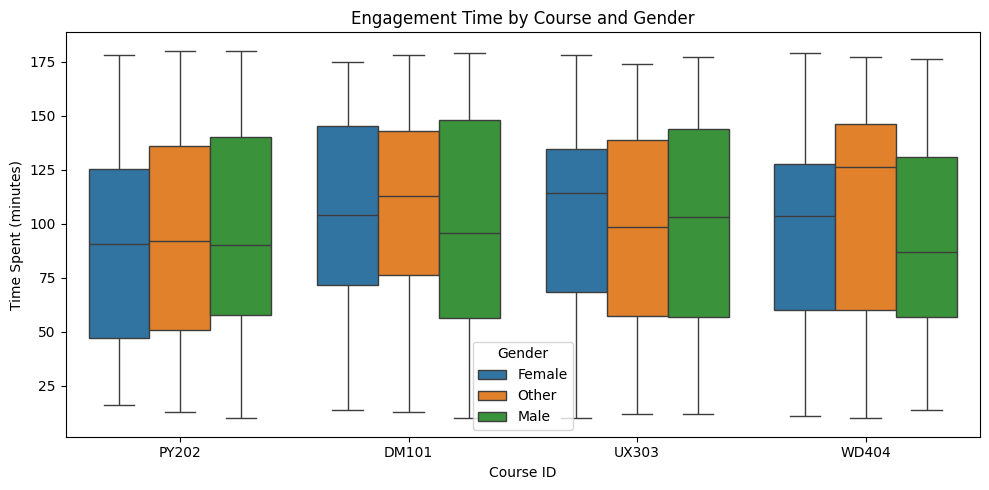

```python
plt.figure(figsize=(10, 5))
sns.boxplot(x='Course_ID', y='Time_Spent_Minutes', hue='Gender', data=merged_data)
plt.title('Engagement Time by Course and Gender')
plt.ylabel('Time Spent (minutes)')
plt.xlabel('Course ID')
plt.tight_layout()
plt.show()
```

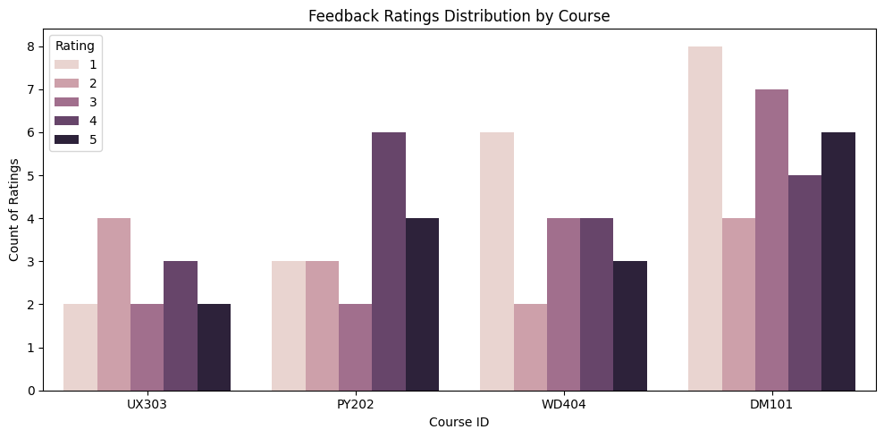

```python
plt.figure(figsize=(10, 5))
sns.countplot(x='Course_ID', hue='Rating', data=Feedback)
plt.title('Feedback Ratings Distribution by Course')
plt.xlabel('Course ID')
plt.ylabel('Count of Ratings')
plt.legend(title='Rating')
plt.tight_layout()
plt.show()
```

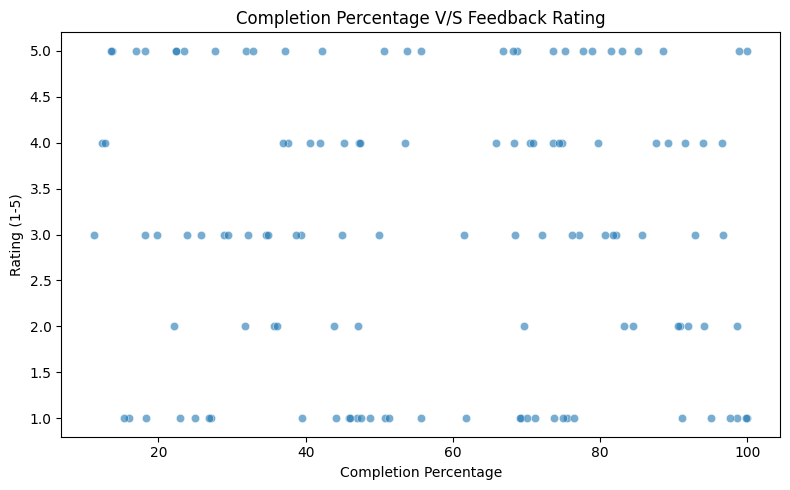

```python
plt.figure(figsize=(8, 5))
sns.scatterplot(x='Completion_Percentage', y='Rating', data=Activity_Feedback, alpha=0.6)
plt.title('Completion Percentage V/S Feedback Rating')
plt.xlabel('Completion Percentage')
plt.ylabel('Rating (1-5)')
plt.tight_layout()
plt.show()
```

```python
# Extract month from date
merged_data['Month'] = merged_data['Date'].dt.month
monthly_engagement = merged_data.groupby('Month')['Time_Spent_Minutes'].mean()
```

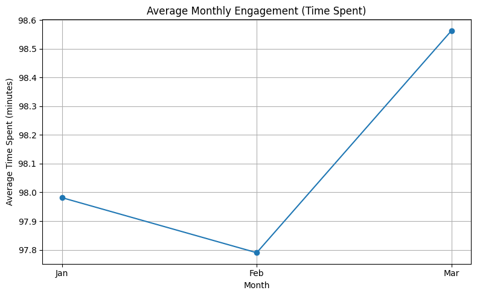

```python
plt.figure(figsize=(8, 5))
monthly_engagement.plot(kind='line', marker='o')
plt.title('Average Monthly Engagement (Time Spent)')
plt.xlabel('Month')
plt.ylabel('Average Time Spent (minutes)')
plt.xticks(range(1, 4), ['Jan', 'Feb', 'Mar'])
plt.grid(True)
plt.tight_layout()
plt.show()
```

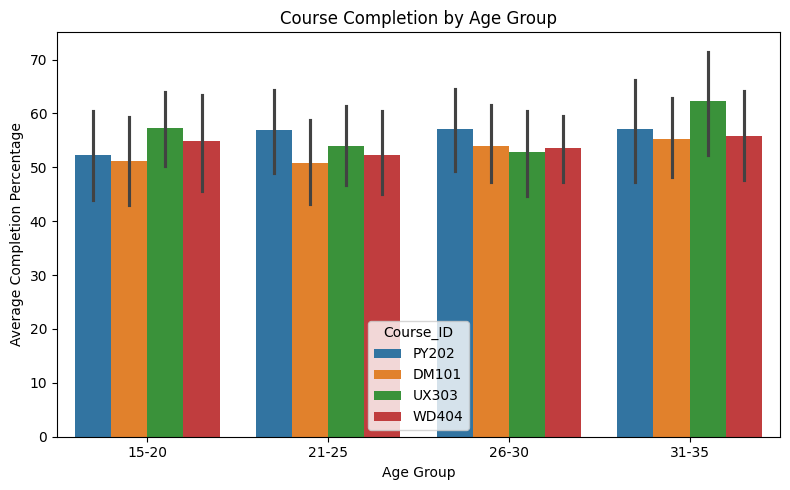

```python
plt.figure(figsize=(8, 5))
sns.barplot(x='Age_Group', y='Completion_Percentage', hue='Course_ID', data=merged_data)
plt.title('Course Completion by Age Group')
plt.xlabel('Age Group')
plt.ylabel('Average Completion Percentage')
plt.tight_layout()
plt.show()
```

# Insights

#### Overall Completion Rate:

**--> The average course completion rate is 54.78% ~ 55%, indicating room for improvement in student retention.**

#### Engagement Patterns:

**--> Students from Kolkata show the highest engagement (104.38 mins), while Chennai has the lowest (90.94 mins).**

**--> Younger students (21-25) are slightly more engaged than older age groups.**

#### Feedback Analysis:

**--> There's a negative correlation (-0.05) between completion rates and feedback ratings.**

**--> Common feedback themes include courses being "Needing Improvement" and "Too fast-paced".**

# Recommendations

#### Course Content Review:

**--> Address the "Too fast-paced" feedback by offering adjustable learning speeds or supplemental materials.**

#### Regional Engagement Strategies:

**--> Investigate why Chennai has lower engagement and develop targeted engagement strategies.**

**--> Replicate successful engagement approaches from Kolkata in other regions.**

#### Personalized Learning Paths:

**--> Create tailored content for high-performing segments (e.g., Others age ranging between 21-25 in Mumbai).**